# Practice 2 - Fraud - Best model and Explainability

Here, in the last step of our Machine Learning model for fraud detection, is to improve our best models (in this case the XGBoost). After importing the selected libraries as well as the "selected" dataset, we will generate a grid with the main hiperparameters in order to find the best model. As a final step, we will study the explainability of the model with the SHAP library with the objetive to find which variables define more the final result in the model.

```python
import pandas as pd
import shap
from sklearn.model_selection import train_test_split
from sklearn.metrics import r2_score, precision_recall_curve, recall_score, precision_score, auc, classification_report, fbeta_score, ConfusionMatrixDisplay, confusion_matrix, accuracy_score, roc_auc_score, roc_curve, precision_recall_curve, average_precision_score
import xgboost
from sklearn.model_selection import train_test_split, GridSearchCV, RandomizedSearchCV
from sklearn.model_selection import GridSearchCV
from aux_func import *
import warnings
warnings.filterwarnings('ignore')

#we set the same seed as in the previous notebook
seed = 12345
```

```python
df = pd.read_csv('../data/processed/df_selected.csv')
df.drop(["Unnamed: 0"], axis=1 , inplace=True)
df.tail()
```

|  | step | transactions_per_step | type | gender | device | connection | age | zone | user_number | user_connections | security_alert | Type_Orig_Des | amount | oldbalanceOrg | newbalanceOrig | oldbalanceDest | newbalanceDest | isFraud |
| --- | --- | --- | --- | --- | --- | --- | --- | --- | --- | --- | --- | --- | --- | --- | --- | --- | --- | --- |
| 1048570 | 1.0 | 0.057957 | 0.001547 | 0.666667 | 0.333333 | 0.001105 | 0.357895 | 1.000000 | 0.666667 | 0.888889 | 0 | 0.001644 | 0.013256 | 0.012322 | 0.008916 | 0.011517 | 0.014629 | 0 |
| 1048571 | 1.0 | 0.057957 | 0.000000 | 0.666667 | 0.333333 | 0.001105 | 0.326316 | 0.000000 | 0.555556 | 0.888889 | 0 | 0.000000 | 0.000992 | 0.002325 | 0.002070 | 0.000000 | 0.000000 | 0 |
| 1048572 | 1.0 | 0.057957 | 0.000000 | 0.333333 | 0.666667 | 0.001105 | 0.273684 | 0.000000 | 0.333333 | 0.111111 | 0 | 0.000000 | 0.001414 | 0.000528 | 0.000164 | 0.000000 | 0.000000 | 0 |
| 1048573 | 1.0 | 0.057957 | 0.000000 | 0.000000 | 0.333333 | 0.001105 | 0.936842 | 0.666667 | 0.111111 | 0.777778 | 0 | 0.000000 | 0.001002 | 0.002327 | 0.002069 | 0.000000 | 0.000000 | 0 |
| 1048574 | 1.0 | 0.057957 | 0.000000 | 0.000000 | 0.666667 | 0.001105 | 0.831579 | 0.666667 | 0.444444 | 0.333333 | 0 | 0.000000 | 0.001145 | 0.002069 | 0.001775 | 0.000000 | 0.000000 | 0 |

```python
X = df.drop('isFraud', axis = 1)
Y = df.isFraud
```

This time, we will merge train and validation in order to just have a train and test.

```python
xtrain, xtest, ytrain, ytest = train_test_split(X, Y, stratify= Y, test_size=0.25, random_state=seed)
```

## XGBoost Grid

To fit a training dataset using XGBoost, an initial prediction is made. Residuals are calculated based on the predicted value and the observed values. A decision tree is created with the residuals using a similarity score of the residuals. The similarity of the data of a leaf is calculated, as well as the similarity gain of the subsequent split. The gains are compared to determine an entity and a threshold for a node. The output value for each leaf is also calculated using the residuals. For classification, the values are generally calculated using log odds and odds ratios. The output of the tree becomes the new residual for the dataset, which is used to build another tree. This process is repeated until the residuals stop decreasing, or the specified number of times. Each subsequent tree learns from the previous trees and is not assigned the same weight, unlike how Random Forest works.

To use this model for prediction, the output of each tree multiplied by a learning rate is added to the initial prediction to arrive at a final value or classification.

```python
params = {"subsample":[0.25,0.5, 0.75, 1],
          "colsample_bytree":[0.25,0.5, 0.75, 1],
          "max_depth":[2, 4, 6, 8, 10, 15, 20],
          "min_child_weight":[1, 2, 3, 4, 5, 10, 15, 20],
          "learning_rate":[0.9,0.6,0.3, 0.1, 0.03, 0.01],
          "n_estimators":[100]
         }
```

Being "**subsample**" the ratio of the training instances, setting it to 0.5 means that XGBoost would randomly sample half of the training data prior to growing trees, preventing overfitting. Subsampling will occur once in every boosting iteration. Hence, we will set it between 0.25 and 1

For "**colsample_bytree**" the range selectes is from 0.25 to 1 due to it defines what percentage of features ( columns ) will be used for building each tree. The set of features for each tree is likely to be different, especially with a low number of features, therefore the range selected.

We also have set the "**max depth**" of the resulting tree from 2 to 20, with a "**minimun child weight**" from 1 to 20. For max depth, we set more lower numbers, due to trees with a high depth can tend to overfit. Similar as with minimun child weight, as we set firts from 1 to 5 and the 10, 15 and 20, as more child weight means a more complex model.

Finally, the **learning rate** we have set it to try values from 0.9 to 0.01 as is the shrinkage it does at every step. Finally we will run the XGBoost 100 times as the **number of estimators** is set to 100.

```python
xgb = xgboost.XGBClassifier()
best_xgb = RandomizedSearchCV(xgb,params,cv=3,scoring="f1_macro",random_state = seed)
best_xgb = best_xgb.fit(xtrain, ytrain)
print(best_xgb.best_params_)
```

```
{'subsample': 0.75, 'n_estimators': 100, 'min_child_weight': 1, 'max_depth': 8, 'learning_rate': 0.3, 'colsample_bytree': 1}
```

```python
y_pred_xgb = best_xgb.predict(xtest)

y_pred_xgb_prob = best_xgb.predict_proba(xtest)
```

```
F2 Score: 0.924467106673776

R2 Score: 0.8039819478309042

Accuracy Score: 0.999786376953125

              precision    recall  f1-score   support

           0       1.00      1.00      1.00    261858
           1       0.98      0.82      0.89       286

    accuracy                           1.00    262144
   macro avg       0.99      0.91      0.95    262144
weighted avg       1.00      1.00      1.00    262144
```

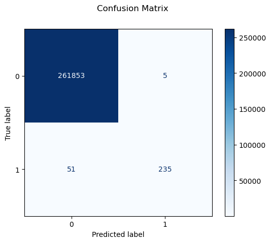

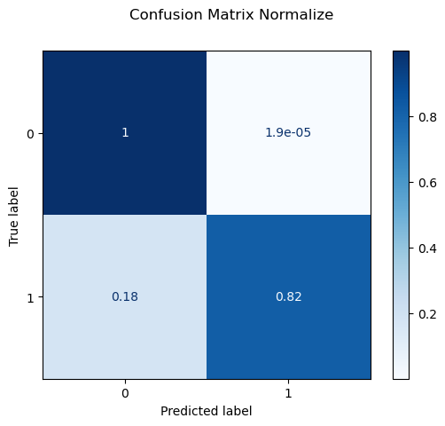

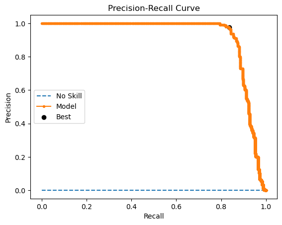

```
Model PR AUC: 0.9185028520701188
Best Threshold=0.354970, F-Score=0.900
```

```python
plot_metrics(ytest, y_pred_xgb, y_pred_xgb_prob, Y)
```

```
No artists with labels found to put in legend.  Note that artists whose label start with an underscore are ignored when legend() is called with no argument.
```

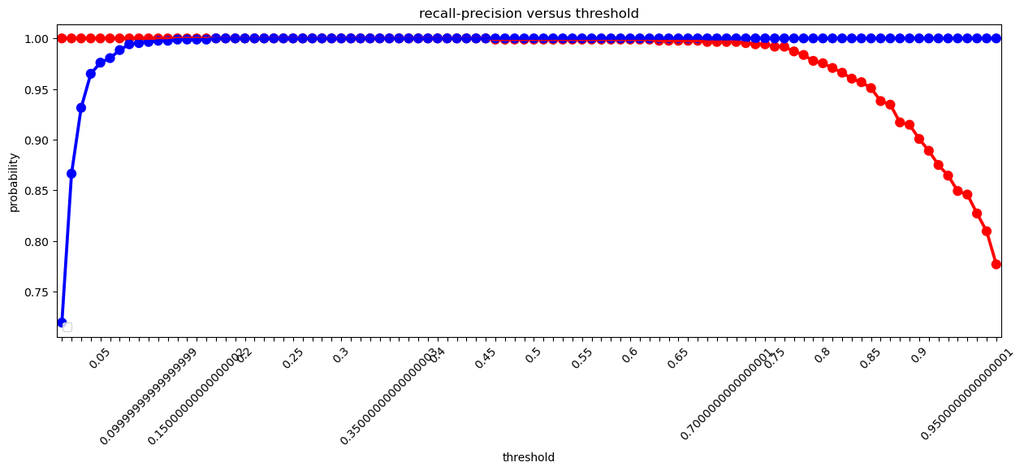

```python
plot_threshold(best_xgb, xtrain, xtest, ytrain, ytest)
```

As we can observe in the plot,the best results can be obtained by setting a threshold between 0.2 and 0.4. Hence, in order to discriminate more possible result we will set it closer to the 0.2. Finally we print the best model.

```python
best_xgb.best_estimator_
```

```
XGBClassifier(base_score=0.5, booster='gbtree', callbacks=None,
              colsample_bylevel=1, colsample_bynode=1, colsample_bytree=1,
              early_stopping_rounds=None, enable_categorical=False,
              eval_metric=None, feature_types=None, gamma=0, gpu_id=-1,
              grow_policy='depthwise', importance_type=None,
              interaction_constraints='', learning_rate=0.3, max_bin=256,
              max_cat_threshold=64, max_cat_to_onehot=4, max_delta_step=0,
              max_depth=8, max_leaves=0, min_child_weight=1, missing=nan,
              monotone_constraints='()', n_estimators=100, n_jobs=0,
              num_parallel_tree=1, predictor='auto', random_state=0, ...)
```

## Model explainability

**Global explainability**

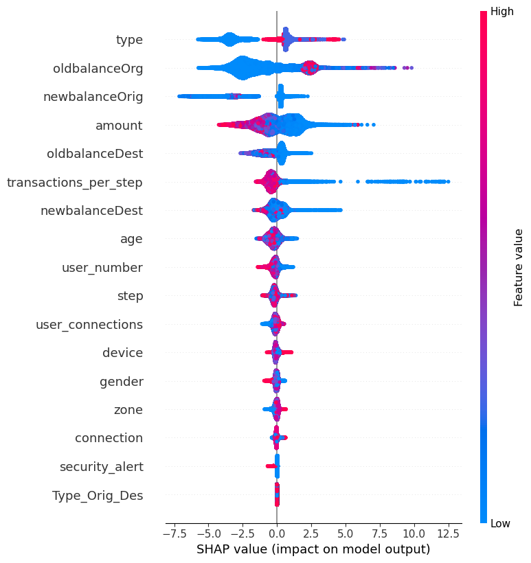

```python
explainer = shap.TreeExplainer(best_xgb.best_estimator_)
shap_values = explainer.shap_values(xtest)
shap.summary_plot(shap_values, xtest)
```

Being the variable **type** one in which we performed a mean enconding, we can conclude that those with 0 were "Cash-in", "debit" and "payment", and as we can see in the plot those tend to 0. The others,"Cash-out" and "Transfer", which had a fraud rate of 0.1547% and 0.6501% respectively tend to the final output to 1.

**Old and new balance origin** are the 2º and 3º respectively features that more affect to the final output for the old balance we can see that the gross low values tend to define the no fraud, meanwhile for the new balance origin, we can hint more high values in the left side of the graph, which means that it tends to mean not fraud.

One of the easier to analyze is the **transactions per step** variable in which the lowee the value the higher tend to fraud, being the more impactful for fraud cases as they can have an impact on the output up to 12.5.

**Local explainability**

```python
shap.initjs()
```

```python
# Using a random sample of the dataframe for better time computation
X_sampled = xtrain.sample(100, random_state=seed)
```

```python
# explain the model's predictions using SHAP values
# (same syntax works for LightGBM, CatBoost, and scikit-learn models)
explainer = shap.TreeExplainer(best_xgb.best_estimator_)
shap_values = explainer.shap_values(X_sampled)
```

```python
# visualize the first prediction's explanation
shap.force_plot(explainer.expected_value, shap_values[0,:], X_sampled.iloc[0,:])
```

```python
shap.force_plot(explainer.expected_value, shap_values, xtrain)
```